# Lab2-Parte2

### R Markdown

> Pre-processamento dos dados

```r
library(readr)
library(dplyr)
graduados <- read_csv("graduados.csv", col_types = cols(matricula = col_character())) %>%
  mutate(matricula = as.factor(matricula))
head(graduados)
```

```
## # A tibble: 6 × 7
##   matricula codigo_disciplina periodo
##      <fctr>             <int>   <dbl>
## 1 183429266           1411169  2013.2
## 2 183429266           1411178  2013.2
## 3 183429266           1411178  2014.1
## 4 183429266           1411183  2014.1
## 5  46876753           1411183  2014.1
## 6 183429266           1411184  2014.2
## # ... with 4 more variables: disciplina <chr>, creditos <int>,
## #   media <dbl>, periodo_ingresso <dbl>
```

Sumario do data frame graduados:

```r
summary(graduados)
```

```
##       matricula     codigo_disciplina    periodo      disciplina
##  1865571312:   73   Min.   :1108089   Min.   :2002   Length:16751
##  3860036619:   68   1st Qu.:1305220   1st Qu.:2006   Class :character
##  3857036627:   67   Median :1411177   Median :2008   Mode  :character
##  1669020028:   65   Mean   :1344411   Mean   :2008
##  3858036635:   65   3rd Qu.:1411187   3rd Qu.:2010
##  106343549 :   64   Max.   :1411197   Max.   :2015
##  (Other)   :16349
##     creditos         media        periodo_ingresso
##  Min.   :2.000   Min.   : 0.000   Min.   :2002
##  1st Qu.:4.000   1st Qu.: 6.500   1st Qu.:2004
##  Median :4.000   Median : 7.500   Median :2006
##  Mean   :3.869   Mean   : 7.247   Mean   :2006
##  3rd Qu.:4.000   3rd Qu.: 8.400   3rd Qu.:2008
##  Max.   :6.000   Max.   :10.000   Max.   :2014
##                  NA's   :252
```

Vamos adicionar CRA ao data frame:

```r
graduados <- graduados %>%
  arrange(matricula)
```

Remoção de medias com NA:

```r
graduados.clean <- graduados %>%
  filter(!is.na(media))
```

Calculo do CRA dos alunos:

```r
graduados.cra <- graduados.clean %>%
  group_by(matricula) %>%
  mutate(cra.contrib = media*creditos) %>%
  summarise(cra = sum(cra.contrib)/sum(creditos))

head(graduados.cra)
```

```
## # A tibble: 6 × 2
##   matricula      cra
##      <fctr>    <dbl>
## 1 103343436 8.357317
## 2 104343425 8.113253
## 3 104343426 7.808219
## 4 104343427 7.453226
## 5 104343429 7.722892
## 6 104343430 8.190909
```

Ajustando os dados para calcular o modelo:

```r
library(reshape2)

graduados.model.input <- graduados.clean %>%
  group_by(matricula,disciplina)  %>%
  filter(media == max(media)) %>%
  ungroup() %>%
  select(matricula,disciplina,media) %>%
  mutate(disciplina = as.factor(gsub(" ",".",disciplina))) %>%
  dcast(matricula ~ disciplina, mean) %>%
  merge(graduados.cra)
```

Vamos tentar responder a seguinte pergunta usando regressão:

*O desempenho dos alunos nos dois primeiros períodos consegue explicar, em algum grau, seus desempenhos no curso como um todo?*

A pergunta anterior pode ser quebrada nas seguintes perguntas:

- Um modelo de regressão múltipla com todas as variáveis é plausível para explicar a variação em y? Em que grau?
- Todas as variáveis são úteis para o modelo de regressão?
- Se a resposta para a pergunta anterior foi não, construa um novo modelo sem essas variáveis e o compare ao modelo com todas as variáveis (e.g. em termos de R2 e RSE).
- Analise os plots de resíduos de cada variável e veja se algum (um ou mais) deles indica não aleatoriedade dos erros.
- Que período consegue explicar melhor o desempenho final (primeiro ou segundo)?
- Use o melhor modelo encontrado para predizer o seu próprio desempenho e compare a predição com o seu CRA atual. Comente o resultado.

#### Disciplinas do primeiro período

- Cálculo Diferencial e Integral I
- Álgebra Vetorial e Geometria Analítica
- Leitura e Produção de Textos
- Programação I
- Introdução à Computação
- Laboratório de Programação I

#### Disciplinas do segundo período

- Cálculo Diferencial e Integral II
- Matemática Discreta
- Programação II
- Teoria dos Grafos
- Fundamentos de Física Clássica
- Laboratório de Programação II

#### Tabela com as disciplinas:

```r
disciplinas <- data.frame(calc1 = graduados.model.input$Cálculo.Diferencial.e.Integral.I,
                     vetorial = graduados.model.input$Álgebra.Vetorial.e.Geometria.Analítica,
                     lpt = graduados.model.input$Leitura.e.Produção.de.Textos,
                     p1 = graduados.model.input$Programação.I,
                     ic = graduados.model.input$Introdução.à.Computação,
                     lp1 = graduados.model.input$Laboratório.de.Programação.I,

                     calc2 = graduados.model.input$Cálculo.Diferencial.e.Integral.II,
                     md = graduados.model.input$Matemática.Discreta,
                     p2 = graduados.model.input$Programação.II,
                     classica = graduados.model.input$Fundamentos.de.Física.Clássica,
                     lp2 = graduados.model.input$Laboratório.de.Programação.II,
                     grafos = graduados.model.input$Teoria.dos.Grafos,
                     cra = graduados.model.input$cra)

disciplinas.clean <- disciplinas %>%
  filter(!is.na(calc1) & !is.na(calc2) & !is.na(vetorial) & !is.na(lpt) & !is.na(grafos) & !is.na(md)& !is.na(classica))
```

> Familiarização

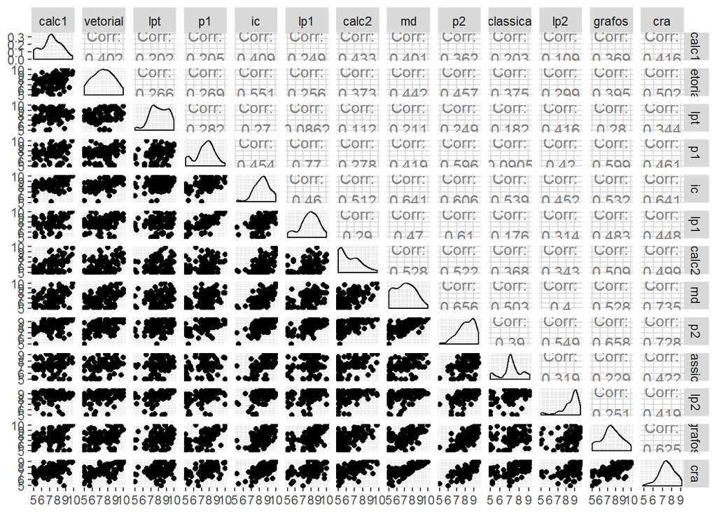

```r
library("GGally")

ggpairs(disciplinas.clean)
```

> Representação visual de relacionamento simples

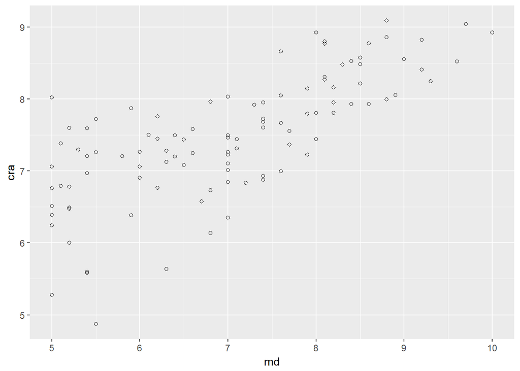

```r
library(ggplot2)

p = ggplot(disciplinas.clean, aes(x=md, y=cra)) +
  geom_point(shape=1)
p
```

Aparentemente há um relacionamento linear entre matematica discreta e o cra.

> Primeiro modelo linear

```r
fit.lm = lm(cra ~ md, data=disciplinas.clean)
print(coef(fit.lm))
```

```
## (Intercept)          md
##    4.105884    0.480305
```

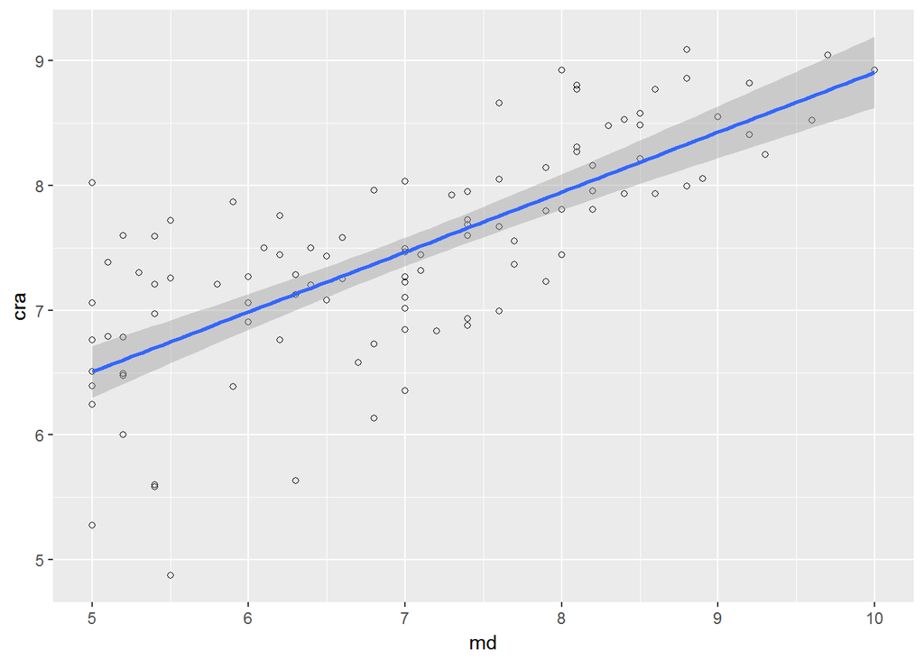

```r
p = p + geom_smooth(method=lm, se=TRUE)
p
```

```r
print(summary(fit.lm))
```

```
##
## Call:
## lm(formula = cra ~ md, data = disciplinas.clean)
##
## Residuals:
##      Min       1Q   Median       3Q      Max
## -1.87309 -0.30741  0.01954  0.31506  1.51494
##
## Coefficients:
##             Estimate Std. Error t value Pr(>|t|)
## (Intercept)  4.10588    0.31224   13.15   <2e-16 ***
## md           0.48030    0.04385   10.95   <2e-16 ***
## ---
## Signif. codes:  0 '***' 0.001 '**' 0.01 '*' 0.05 '.' 0.1 ' ' 1
##
## Residual standard error: 0.5844 on 102 degrees of freedom
## Multiple R-squared:  0.5405, Adjusted R-squared:  0.536
## F-statistic:   120 on 1 and 102 DF,  p-value: < 2.2e-16
```

> Examinar suposições da regressão linear

```r
print(mean(fit.lm$residuals))
```

```
## [1] 4.863272e-19
```

```
Está perto de zero.
```

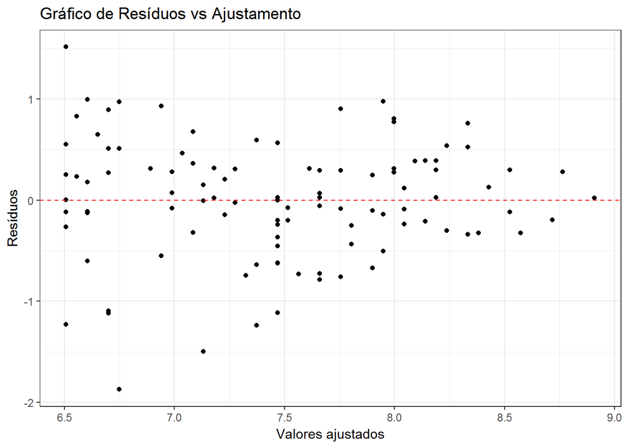

```r
require(ggplot2)
p1 = ggplot(fit.lm, aes(.fitted, .resid)) +
    geom_point()
p1 = p1 + geom_hline(yintercept=0, col="red", linetype="dashed")
p1 = p1 + xlab("Valores ajustados") + ylab("Resíduos")
p1 = p1 + ggtitle("Gráfico de Resíduos vs Ajustamento") +
    theme_bw()
p1
```

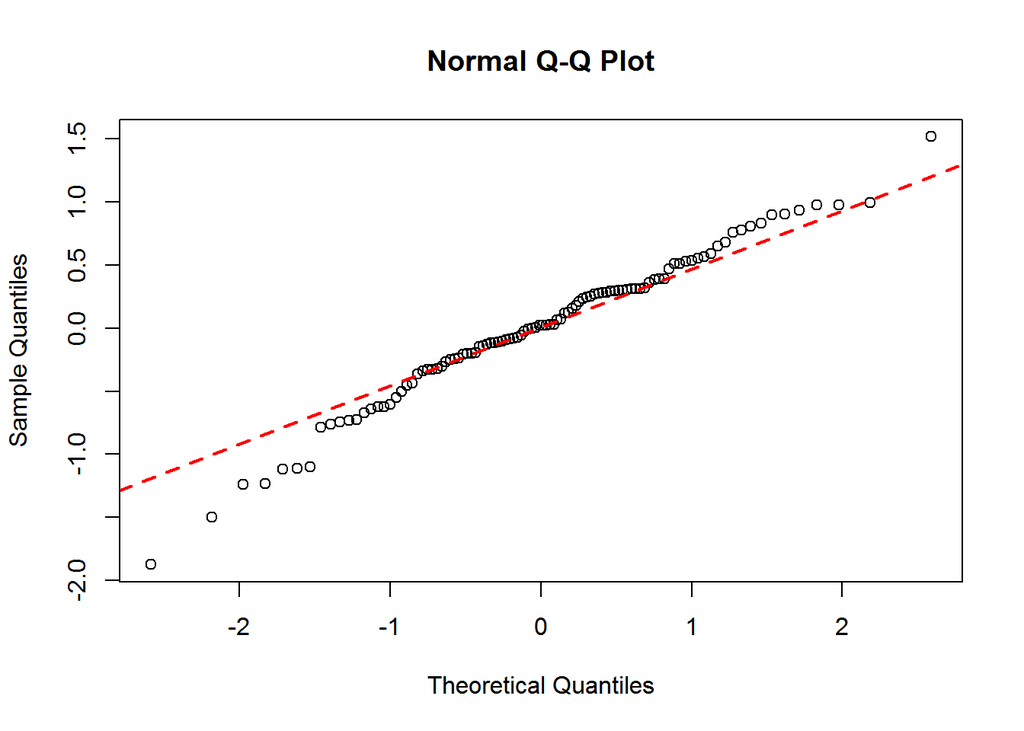

```
Qqplot esta ajustado à linha reta.
```

```r
qqnorm(fit.lm$residuals)
qqline(fit.lm$residuals, col = 2,lwd=2,lty=2)
```

### Regressão multipla - Considerando todas as variaveis

```r
fit.mult <- lm(cra  ~ ., data=disciplinas.clean)
summary(fit.mult)
```

```
##
## Call:
## lm(formula = cra ~ ., data = disciplinas.clean)
##
## Residuals:
##     Min      1Q  Median      3Q     Max
## -1.8273 -0.2988  0.1069  0.2796  1.0032
##
## Coefficients:
##             Estimate Std. Error t value Pr(>|t|)
## (Intercept)  1.33894    0.59783   2.240  0.02758 *
## calc1        0.02121    0.04907   0.432  0.66661
## vetorial     0.04443    0.04762   0.933  0.35327
## lpt          0.09172    0.05167   1.775  0.07925 .
## p1          -0.02593    0.07684  -0.337  0.73660
## ic           0.10196    0.08639   1.180  0.24098
## lp1         -0.02472    0.07450  -0.332  0.74082
## calc2       -0.00100    0.05302  -0.019  0.98499
## md           0.23935    0.05863   4.083 9.63e-05 ***
## p2           0.29214    0.09553   3.058  0.00293 **
## classica    -0.01024    0.06120  -0.167  0.86745
## lp2         -0.02848    0.06666  -0.427  0.67024
## grafos       0.09620    0.06302   1.526  0.13040
## ---
## Signif. codes:  0 '***' 0.001 '**' 0.01 '*' 0.05 '.' 0.1 ' ' 1
##
## Residual standard error: 0.5046 on 90 degrees of freedom
##   (1 observation deleted due to missingness)
## Multiple R-squared:  0.6889, Adjusted R-squared:  0.6474
## F-statistic: 16.61 on 12 and 90 DF,  p-value: < 2.2e-16
```

```r
print(coef(fit.mult))
```

```
##  (Intercept)        calc1     vetorial          lpt           p1
##  1.338944052  0.021209294  0.044433019  0.091718147 -0.025926220
##           ic          lp1        calc2           md           p2
##  0.101963159 -0.024717284 -0.001000451  0.239354263  0.292143607
##     classica          lp2       grafos
## -0.010243349 -0.028478672  0.096199219
```

```r
print(mean(fit.mult$residuals))
```

```
## [1] -1.452278e-17
```

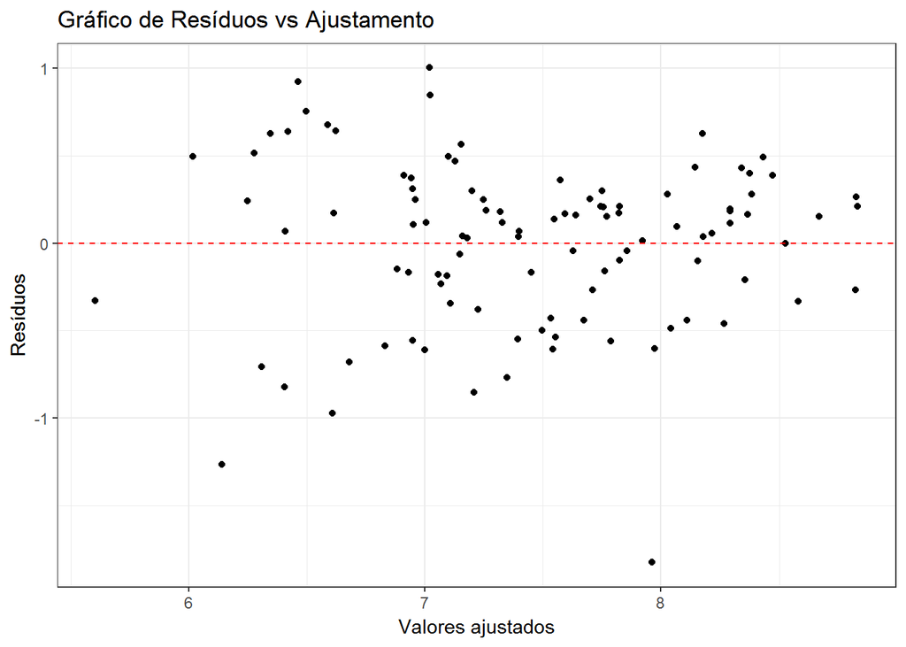

```r
p1 = ggplot(fit.mult, aes(.fitted, .resid)) +
  geom_point()
p1 = p1 + geom_hline(yintercept=0, col="red", linetype="dashed")
p1 = p1 + xlab("Valores ajustados") + ylab("Resíduos")
p1 = p1 + ggtitle("Gráfico de Resíduos vs Ajustamento") +
  theme_bw()
p1
```

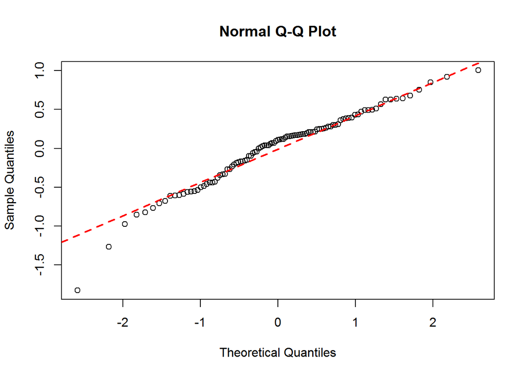

```r
qqnorm(fit.mult$residuals)
qqline(fit.mult$residuals, col = 2,lwd=2,lty=2)
```

### Regressão multipla - Considerando as disciplinas do primeiro periodo

```r
fit.pp <- lm(cra  ~ calc1 +
            vetorial +
            p1 +
            lpt +
            ic +
            lp1,
          data=disciplinas.clean)
summary(fit.pp)
```

```
##
## Call:
## lm(formula = cra ~ calc1 + vetorial + p1 + lpt + ic + lp1, data = disciplinas.clean)
##
## Residuals:
##      Min       1Q   Median       3Q      Max
## -2.50445 -0.33043  0.08777  0.39468  1.14827
##
## Coefficients:
##             Estimate Std. Error t value Pr(>|t|)
## (Intercept)  1.29099    0.67005   1.927 0.056973 .
## calc1        0.08196    0.05666   1.446 0.151311
## vetorial     0.09873    0.05745   1.718 0.088957 .
## p1           0.06176    0.08391   0.736 0.463529
## lpt          0.10564    0.05872   1.799 0.075142 .
## ic           0.33606    0.08905   3.774 0.000278 ***
## lp1          0.09525    0.08695   1.095 0.276071
## ---
## Signif. codes:  0 '***' 0.001 '**' 0.01 '*' 0.05 '.' 0.1 ' ' 1
##
## Residual standard error: 0.6204 on 96 degrees of freedom
##   (1 observation deleted due to missingness)
## Multiple R-squared:  0.4984, Adjusted R-squared:  0.4671
## F-statistic:  15.9 on 6 and 96 DF,  p-value: 1.311e-12
```

```r
print(coef(fit.pp))
```

```
## (Intercept)       calc1    vetorial          p1         lpt          ic
##  1.29099400  0.08195758  0.09872709  0.06176014  0.10563602  0.33606339
##         lp1
##  0.09524878
```

```r
print(mean(fit.pp$residuals))
```

```
## [1] -1.162991e-17
```

### Regressão multipla - Considerando as disciplinas do segundo periodo

```r
fit.sp <- lm(cra  ~ calc2 +
            md +
            p2 +
            classica +
            lp2 +
            grafos,
          data=disciplinas.clean)

summary(fit.sp)
```

```
##
## Call:
## lm(formula = cra ~ calc2 + md + p2 + classica + lp2 + grafos,
##     data = disciplinas.clean)
##
## Residuals:
##      Min       1Q   Median       3Q      Max
## -1.61553 -0.36634  0.06087  0.34975  1.00704
##
## Coefficients:
##             Estimate Std. Error t value Pr(>|t|)
## (Intercept) 1.960386   0.515415   3.804  0.00025 ***
## calc2       0.003025   0.049868   0.061  0.95175
## md          0.257043   0.056305   4.565 1.46e-05 ***
## p2          0.270335   0.089310   3.027  0.00316 **
## classica    0.040969   0.055854   0.733  0.46502
## lp2         0.023103   0.058272   0.396  0.69263
## grafos      0.133424   0.055874   2.388  0.01888 *
## ---
## Signif. codes:  0 '***' 0.001 '**' 0.01 '*' 0.05 '.' 0.1 ' ' 1
##
## Residual standard error: 0.5091 on 97 degrees of freedom
## Multiple R-squared:  0.6683, Adjusted R-squared:  0.6478
## F-statistic: 32.58 on 6 and 97 DF,  p-value: < 2.2e-16
```

```r
print(coef(fit.sp))
```

```
## (Intercept)       calc2          md          p2    classica         lp2
## 1.960385951 0.003025444 0.257043176 0.270335284 0.040969211 0.023103202
##      grafos
## 0.133424202
```

```r
print(mean(fit.sp$residuals))
```

```
## [1] 1.183722e-17
```

### Regressão multipla - Considerando as disciplinas menos calculo 2

```r
fit.test <- lm(cra  ~ calc1 +
            vetorial +
            p1 +
            lpt +
            ic +
            classica +
            lp1 +
            md +
            p2 +
            lp2 +
            grafos,
          data=disciplinas.clean)

summary(fit.test)
```

```
##
## Call:
## lm(formula = cra ~ calc1 + vetorial + p1 + lpt + ic + classica +
##     lp1 + md + p2 + lp2 + grafos, data = disciplinas.clean)
##
## Residuals:
##     Min      1Q  Median      3Q     Max
## -1.8274 -0.3000  0.1077  0.2798  1.0047
##
## Coefficients:
##             Estimate Std. Error t value Pr(>|t|)
## (Intercept)  1.33941    0.59403   2.255  0.02655 *
## calc1        0.02099    0.04744   0.443  0.65917
## vetorial     0.04443    0.04736   0.938  0.35059
## p1          -0.02582    0.07622  -0.339  0.73555
## lpt          0.09189    0.05054   1.818  0.07230 .
## ic           0.10184    0.08565   1.189  0.23754
## classica    -0.01035    0.06058  -0.171  0.86465
## lp1         -0.02466    0.07403  -0.333  0.73979
## md           0.23923    0.05796   4.128  8.1e-05 ***
## p2           0.29204    0.09485   3.079  0.00275 **
## lp2         -0.02872    0.06507  -0.441  0.65998
## grafos       0.09589    0.06058   1.583  0.11692
## ---
## Signif. codes:  0 '***' 0.001 '**' 0.01 '*' 0.05 '.' 0.1 ' ' 1
##
## Residual standard error: 0.5018 on 91 degrees of freedom
##   (1 observation deleted due to missingness)
## Multiple R-squared:  0.6889, Adjusted R-squared:  0.6513
## F-statistic: 18.32 on 11 and 91 DF,  p-value: < 2.2e-16
```

```r
print(coef(fit.test))
```

```
## (Intercept)       calc1    vetorial          p1         lpt          ic
##  1.33940977  0.02099216  0.04443391 -0.02582173  0.09189428  0.10183637
##    classica         lp1          md          p2         lp2      grafos
## -0.01035492 -0.02466427  0.23923346  0.29203863 -0.02871968  0.09589469
```

```r
print(mean(fit.test$residuals))
```

```
## [1] -1.646356e-17
```

**Um modelo de regressão múltipla com todas as variáveis é plausível para explicar a variação em y? Em que grau?**

O modelo com multiplas variaveis conseguiu explicar melhor os dados que o modelo com apenas uma varivel. Neste caso o aumento de complexidade foi acompanhada de melhoria do modelo.

**Todas as variáveis são úteis para o modelo de regressão?**

A remoção de calculo 2 do modelo com todas as variaveis não afetou o resultado de R2.

**Se a resposta para a pergunta anterior foi não, construa um novo modelo sem essas variáveis e o compare ao modelo com todas as variáveis (e.g. em termos de R2 e RSE).**

Modelo com todas as variaveis: R2 = 0.6889 RSE = 0.5046

Modelo com todas as variaveis menos Calculo 2: R2 = 0.6889 RSE = 0.5018

Houve uma melhoria muito pequena nos residuos.

**Analise os plots de resíduos de cada variável e veja se algum (um ou mais) deles indica não aleatoriedade dos erros.** Todos os plots acima (de residuo e qqplot) apresentam um bom comportamento.

**Que período consegue explicar melhor o desempenho final (primeiro ou segundo)?**

O segundo periodo consegue apresenta um melhor R2, portanto consegue explicar melhor a variancia dos dados.

**Use o melhor modelo encontrado para predizer o seu próprio desempenho e compare a predição com o seu CRA atual. Comente o resultado.**

Considerando a regressão com todas as variaveis. O resultado foi o seguinte:

```r
newdata = data.frame(calc1 = 5.7,
                     vetorial = 5.9,
                     lpt = 7.8,
                     p1 = 8.7,
                     ic = 8.2,
                     classica = 7.6,
                     lp1 = 8.7,
                     calc2 = 5.8,
                     md = 5.8,
                     p2 = 7.6,
                     lp2 = 7.0,
                     grafos = 5.4)

#Com todas as variaveis
predict(fit.mult, newdata)
```

```
##        1
## 6.677912
```

```r
#Com a remocao de calc2
predict(fit.test, newdata)
```

```
##        1
## 6.678974
```

A previsão foi boa, considerando os dados que recebemos. Meu CRA atual é de 7.33.

A previsão com a remocao da variavel calc2 foi a que se aproximou mais do valor real. Acredito que adicionando mais algumas notas do terceiro periodo, por exemplo,poderia melhorar a predição do meu modelo.

> Conclusao: O CRA pode ser estimado com as notas do primeiro e segundo periodo.